# Analyzing Valorant Agent and Map Pick + Win Rates

Alan Wang

### Introduction

Valorant is a Multiplayer First Hero Person Shooter game developed by Riot Games. With over 12 million active users in 2021, Valorant has recently gotten popular over the COVID pandemic. With its rise in popularity, Riot Games has hosted tournaments involving players from all over the world.

The game is quite simple, it is a 5v5 tacitcal shooter, one side is the attackers and one side is the diefenders. The attackers are supposed to plant and detonate a spike within a map, and the defenders are to defend the site and defuse the spike if it is planted. Each game is first to 13 with 24 rounds in the main game, with a win by two condition attached. At round 12, there is a switch and attackers become defenders and defenders become attackers. If the match ends up being 12-12 overtime (2 rounds one on each side) until one team wins two rounds in a row. Players can currently play on a 7 maps, 17 agents, and several primary and secondary weapons to choose from. More information can be found here: https://playvalorant.com/en-us/news/announcements/beginners-guide/

Currently, a website called Blitz currently keeps track of data, luckily for us someone has already scraped the data and compiled it into datasets for us (/u/IronNinja) in the following repository: https://github.com/IronicNinja/valorant-stats. These statistics are a little bit outdated (July 2021) but they will suffice for the tutorial. As of this time, there are only 6 Maps and 15 Agents.

In this tutorial, our goal is to tidy the in-game data as well as provide some insight into which operators are the most successful in terms of win rate. I hope this analysis is helpful in determining what temp compositions work, as each agent is unique and serves a different function, as well as maybe help people are new to the game choose the first agent that they want to learn. Throughout this tutorial we will be coding in Python 3 and making use of many libraries (pandas, numpy, seaborn, etc.

### Getting, pre-processing, and tidying data

To get and tidy data we will be making use of pandas as well as numpy. All of the data used for this project can be found here: https://github.com/IronicNinja/valorant-stats

Using pd.read_csv, we are able to import and read all of the data files that we need. We also get rid of all the commas so that our datafiles are more readable. The clean function below is used to do this. Whenever we read a file in, just use the clean function so that the data is more readable.

```python
import pandas as pd
import numpy as np
from datetime import datetime, timedelta
import gc
import matplotlib.pyplot as plt
from scipy.stats import f
import seaborn as sns
from sklearn import model_selection
from sklearn import linear_model
from sklearn.linear_model import LinearRegression
from sklearn import preprocessing
from sklearn.preprocessing import LabelEncoder
import statsmodels.formula.api as smf
```

```python
def clean(df):
    if "Unnamed: 0" in df.columns:
        df.drop("Unnamed: 0", axis=1, inplace=True)

    for col in df.columns:
        df[col] = df[col].astype(str).str.rstrip('%').str.replace(',', '')
        try:
            df[col] = df[col].astype(float)
        except:
            pass
    df.set_index(df.columns[0], inplace=True)
    return df
```

```python
general_ranks_list = ["Iron", "Bronze", "Silver", "Gold", "Platinum", "Diamond"]
ranks_list = np.array([f"{rank} {num}" for rank in general_ranks_list for num in range(1, 4)])
num_ranks = len(ranks_list)
```

### Reading data

```python
example_agent = clean(pd.read_csv(f"https://raw.githubusercontent.com/IronicNinja/valorant-stats/master/agents_data/all/agents_competitive_tier%3D3.csv"))
example_agent
```

| Agent Name | KD | Kills | Deaths | Assists | Win Rate | Pick Rate | ACS | First Blood | Num Matches |
| --- | --- | --- | --- | --- | --- | --- | --- | --- | --- |
| Sage | 0.78 | 11.5 | 14.7 | 4.2 | 51.9 | 18.8 | 164.0 | 11.7 | 9231.0 |
| Raze | 0.90 | 13.1 | 14.6 | 4.3 | 44.2 | 11.7 | 207.0 | 13.9 | 5763.0 |
| Jett | 1.01 | 14.3 | 14.1 | 4.1 | 53.8 | 10.8 | 210.0 | 15.2 | 5304.0 |
| Reyna | 1.01 | 14.7 | 14.6 | 3.9 | 48.5 | 10.3 | 224.0 | 14.7 | 5049.0 |
| Viper | 0.80 | 11.0 | 13.9 | 4.3 | 49.3 | 6.9 | 165.0 | 11.8 | 3417.0 |
| Killjoy | 0.86 | 12.6 | 14.7 | 4.3 | 51.6 | 6.6 | 185.0 | 12.2 | 3264.0 |
| Phoenix | 0.99 | 13.1 | 13.3 | 4.2 | 62.3 | 6.3 | 202.0 | 14.7 | 3111.0 |
| Omen | 0.85 | 12.6 | 14.7 | 4.5 | 53.4 | 6.0 | 189.0 | 14.0 | 2958.0 |
| Sova | 0.80 | 12.1 | 15.1 | 5.4 | 49.0 | 5.1 | 182.0 | 13.4 | 2499.0 |
| Brimstone | 0.89 | 12.8 | 14.3 | 5.6 | 54.3 | 4.8 | 192.0 | 11.1 | 2346.0 |
| Skye | 0.76 | 10.4 | 13.7 | 3.6 | 52.6 | 3.9 | 149.0 | 10.9 | 1938.0 |
| Yoru | 0.86 | 12.2 | 14.2 | 3.3 | 52.6 | 3.9 | 186.0 | 14.9 | 1938.0 |
| Cypher | 0.95 | 14.5 | 15.3 | 5.0 | 36.4 | 2.3 | 193.0 | 8.8 | 1122.0 |
| Breach | 0.75 | 11.4 | 15.2 | 4.4 | 52.4 | 2.2 | 161.0 | 11.3 | 1071.0 |
| Astra | 1.20 | 15.3 | 12.8 | 4.8 | 50.0 | 0.4 | 217.0 | 8.2 | 204.0 |

A quick summary of what each column + row header means:

- row headers are all the agent names
- KD is kill-death ratio (how many enemies killed per time dying during the period of one game)
- Kills is how many kills the respective agent has at the end of a game
- Deaths is how many deaths the respective agent has at the end of a game
- Assists is how many times the agent has assisted in helping another teammate get a kill on an enemy agent per game
- Win rate is the % the agent has won overall across the maps as of July 2021
- Pick rate is the % the agent is picked to be played during the game
- ACS is average combat score, which has many factors but in summary: a higher ACS is typically "better"
- First blood is a % estimating how often the agent gets the first kill in a round
- Num Matches is how many times the agent has been played in history. (As of July 2021)

Because we want a look at the entire game across all skill levels, we will have to compile the averages for all of the agent data throughout the ranks.

```python
KD_list = []
winrate_list = []
agent_pickrate_list = []
acs_list = []
firstblood_list = []
num_matches_lst = []
for i in range(3, 3 + len(ranks_list)):
    tmp_agents_df = clean(pd.read_csv(f"https://raw.githubusercontent.com/IronicNinja/valorant-stats/master/agents_data/all/agents_competitive_tier%3D{i}.csv"))
    KD_list.append(tmp_agents_df['KD'])
    winrate_list.append(tmp_agents_df['Win Rate'])
    agent_pickrate_list.append(tmp_agents_df['Pick Rate'])
    acs_list.append(tmp_agents_df['ACS'])
    firstblood_list.append(tmp_agents_df['First Blood'])
    num_matches_lst.append(tmp_agents_df['Num Matches'])

num_matches_df = pd.DataFrame(num_matches_lst, index=ranks_list)
kd_df = pd.DataFrame(KD_list, index=ranks_list)
winrate_df = pd.DataFrame(winrate_list, index=ranks_list)
agent_pickrate_df = pd.DataFrame(agent_pickrate_list, index=ranks_list)
acs_df = pd.DataFrame(acs_list, index=ranks_list)
firstblood_df = pd.DataFrame(firstblood_list, index=ranks_list)
```

### Exploratory Data Analysis

Now that we have compiled all our data, let's try doing some EDA on the data that we have. We'll be using the Average Combat Score (ACS) and the Win-rate per agent to see if there is a relationship between the acs and winrates (If you've been following along these are located in the acs_df and the winrate_df). Since they have already provided values for each of them across the ranks, we'll be averaging all the ranks ACS and Winrates to get an easier to read graph. To do this, we will be making a new dataframe containing the averages and then graphing it using seaborn.

```python
compiled = pd.DataFrame(winrate_df.mean(), columns=["Win Rate"])
compiled["ACS"] = pd.DataFrame(acs_df.mean(), columns=["ACS"])
compiled["Pick Rate"] = pd.DataFrame(agent_pickrate_df.mean(), columns=["Pick Rate"] )
compiled["Matches"] = pd.DataFrame(num_matches_df.sum(), columns=["Num Matches"])
compiled.index.name = 'Agent'
compiled.reset_index(inplace=True)
compiled
```

|  | Agent | Win Rate | ACS | Pick Rate | Matches |
| --- | --- | --- | --- | --- | --- |
| 0 | Sage | 53.255556 | 189.000000 | 14.472222 | 283509.0 |
| 1 | Raze | 52.122222 | 234.222222 | 7.927778 | 152541.0 |
| 2 | Jett | 50.605556 | 238.388889 | 14.533333 | 260661.0 |
| 3 | Reyna | 50.038889 | 246.444444 | 14.688889 | 285855.0 |
| 4 | Viper | 53.300000 | 201.333333 | 5.533333 | 100470.0 |
| 5 | Killjoy | 53.655556 | 200.166667 | 6.638889 | 133926.0 |
| 6 | Phoenix | 48.794444 | 226.666667 | 4.172222 | 85782.0 |
| 7 | Omen | 48.511111 | 197.000000 | 7.955556 | 161415.0 |
| 8 | Sova | 48.516667 | 197.500000 | 7.488889 | 141474.0 |
| 9 | Brimstone | 51.855556 | 197.055556 | 3.538889 | 74715.0 |
| 10 | Skye | 50.511111 | 194.166667 | 3.394444 | 63648.0 |
| 11 | Yoru | 41.935294 | 211.882353 | 2.094118 | 41973.0 |
| 12 | Cypher | 47.072222 | 191.166667 | 4.461111 | 77163.0 |
| 13 | Breach | 49.570588 | 194.235294 | 1.905882 | 38148.0 |
| 14 | Astra | 45.361111 | 197.944444 | 1.394444 | 22338.0 |

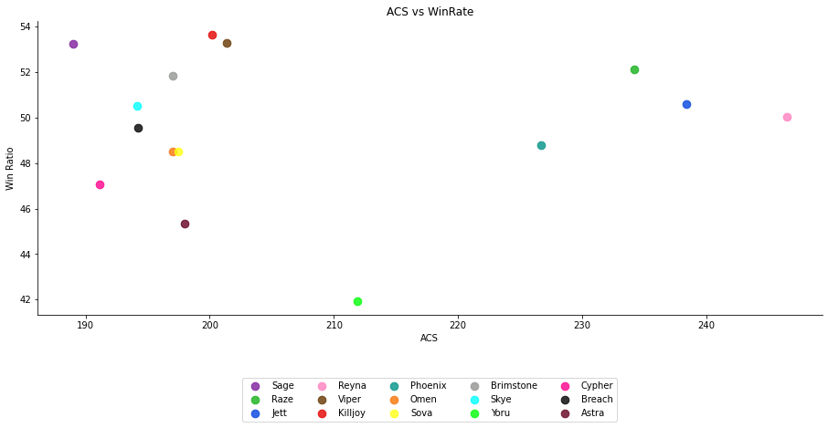

```python
colors = ["purple", "green", "blue", "pink", "brown", "red", "teal", "orange", "yellow", "grey",
          "cyan", "bright green", "hot pink", "black", "maroon"]
new_palette = sns.xkcd_palette(colors)
sns.lmplot(x="ACS", y="Win Rate", data=compiled, fit_reg=False,
        hue='Agent', legend=False, palette=new_palette, height=5, aspect=2.5, scatter_kws={"s": 75})
plt.legend(loc=9, bbox_to_anchor=(0.5, -0.2), ncol=5)
plt.title('ACS vs WinRate')
plt.xlabel('ACS')
plt.ylabel('Win Ratio')
```

Although from first glance it seems as though there is. a higher winrate for agents with lower ACS. But, in fact, there is something else we must consider, which is that each agent plays a different role in the game: Sentinel, controller, and duelist. This means that ACS scores might actual be biased as duelists tend to have higher ACS than controllers and sentinels. Because of this, ACS does not seem to affect the actual winrate of champions, as all of the higher ACS scores are from the duelists while all of them lower scores are results of controllers and sentinels. To find more about the roles in the game look here: https://playvalorant.com/en-us/news/announcements/beginners-guide/ As such, we should use a different parameter aside from ACS such as pickrate vs winrate. We will be doing this below.

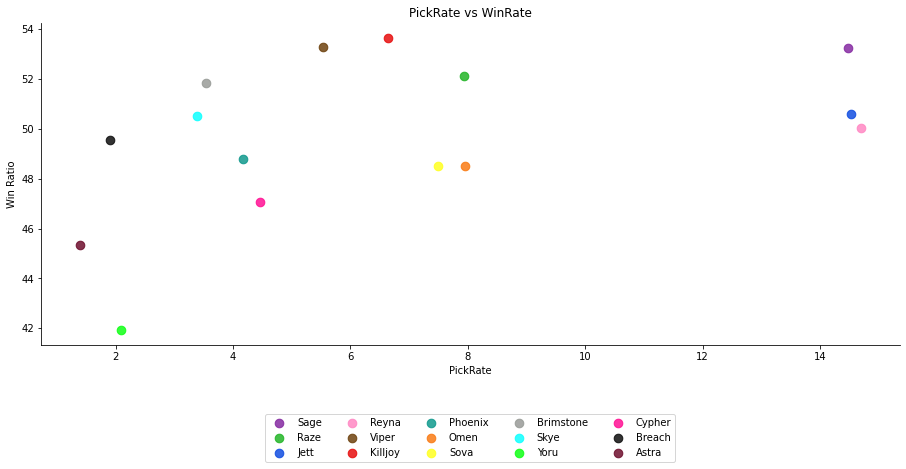

```python
sns.lmplot(x="Pick Rate", y="Win Rate", data=compiled, fit_reg=False,
        hue='Agent', legend=False, palette=new_palette, height=5, aspect=2.5, scatter_kws={"s": 75})
plt.legend(loc=9, bbox_to_anchor=(0.5, -0.2), ncol=5)
plt.title('PickRate vs WinRate')
plt.xlabel('PickRate')
plt.ylabel('Win Ratio')
```

This plot might tell us a more since the agents with above 14% pick rate all have above a 50% winrate. However, there are also agents that have below 8% pickrate and still boast above 50% winrates. This could be due to the fact that the game is still relatively new, so the people who play these lower pick agents tend to be "one-tricks" (people who look extensively into how to us the agents uniqueness to its best advantage) garunteeing wins for their team. However, aside from this most agents that have a sub 6% pick rate have a sub 50% winrate. To look more into it, we should check how many matches each agent has played.

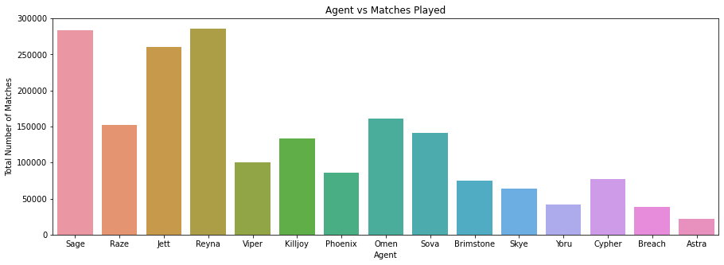

```python
plt.figure(figsize=(15,5))
sns.barplot(x="Agent", y="Matches", data=compiled)
plt.title('Agent vs Matches Played')
plt.xlabel('Agent')
plt.ylabel('Total Number of Matches')
```

Now it starts to make a little more sense, as Sage Jett and Reyna, the three highest pick rates, boast higher winrates (50%+) and Killjoy, Raze, and Viper see less play, however, both raze and viper are known across the community as "one-tricks" which could suggest the higher win-rate. Something else we might want to check is how well each agent performs on each map. This is where the maps design and layout actually affects how effective the respective agent is on the map.

```python
#Going through each map, compiling the winrates for each rank for each map, averaging, and then compiling it all into
#one big datafile
ascent_list = []
for i in range(3, 3 + len(ranks_list)):
    tmp_agents_df = clean(pd.read_csv(f"https://raw.githubusercontent.com/IronicNinja/valorant-stats/master/agents_data/ascent/agents_competitive_tier%3D{i}.csv"))
    ascent_list.append(tmp_agents_df['Win Rate'])
ascent_df = pd.DataFrame(ascent_list, index=ranks_list)
mapWR = pd.DataFrame(ascent_df.mean(), columns=["Ascent"])

haven_list = []
for i in range(3, 3 + len(ranks_list)):
    tmp_agents_df = clean(pd.read_csv(f"https://raw.githubusercontent.com/IronicNinja/valorant-stats/master/agents_data/haven/agents_competitive_tier%3D{i}.csv"))
    haven_list.append(tmp_agents_df['Win Rate'])
haven_df = pd.DataFrame(haven_list, index=ranks_list)
mapWR["Haven"] = pd.DataFrame(haven_df.mean(), columns=["Win Rate"])

split_list = []
for i in range(3, 3 + len(ranks_list)):
    tmp_agents_df = clean(pd.read_csv(f"https://raw.githubusercontent.com/IronicNinja/valorant-stats/master/agents_data/split/agents_competitive_tier%3D{i}.csv"))
    split_list.append(tmp_agents_df['Win Rate'])
split_df = pd.DataFrame(split_list, index=ranks_list)
mapWR["Split"] = pd.DataFrame(split_df.mean(), columns=["Win Rate"])

breeze_list = []
for i in range(3, 3 + len(ranks_list)):
    tmp_agents_df = clean(pd.read_csv(f"https://raw.githubusercontent.com/IronicNinja/valorant-stats/master/agents_data/breeze/agents_competitive_tier%3D{i}.csv"))
    breeze_list.append(tmp_agents_df['Win Rate'])
breeze_df = pd.DataFrame(breeze_list, index=ranks_list)
mapWR["Breeze"] = pd.DataFrame(breeze_df.mean(), columns=["Win Rate"])

# Unfortunately there is no data for icebox currently so we will just take it out
# icebox_list = []
# for i in range(3, 3 + len(ranks_list)):
#     tmp_agents_df = clean(pd.read_csv(f"https://raw.githubusercontent.com/IronicNinja/valorant-stats/master/agents_data/breeze/agents_competitive_tier%3D{i}.csv"))
#     icebox_list.append(tmp_agents_df['Win Rate'])
# icebox_df = pd.DataFrame(icebox_list, index=ranks_list)
# mapWR["icebox"] = pd.DataFrame(icebox_df.mean(), columns=["Win Rate"])

bind_list = []
for i in range(3, 3 + len(ranks_list)):
    tmp_agents_df = clean(pd.read_csv(f"https://raw.githubusercontent.com/IronicNinja/valorant-stats/master/agents_data/bind/agents_competitive_tier%3D{i}.csv"))
    bind_list.append(tmp_agents_df['Win Rate'])
bind_df = pd.DataFrame(bind_list, index=ranks_list)
mapWR["Bind"] = pd.DataFrame(bind_df.mean(), columns=["Win Rate"])

mapWR
```

|  | Ascent | Haven | Split | Breeze | Bind |
| --- | --- | --- | --- | --- | --- |
| Sage | 48.111111 | 51.777778 | 55.031250 | 50.033333 | 51.700000 |
| Raze | 51.522222 | 52.087500 | 52.731250 | 53.464706 | 50.988235 |
| Reyna | 50.711111 | 52.450000 | 45.831250 | 47.527778 | 47.477778 |
| Jett | 51.622222 | 51.611111 | 55.437500 | 51.972222 | 49.511765 |
| Killjoy | 51.000000 | 48.688235 | 54.175000 | 47.235294 | 56.323529 |
| Viper | 49.947059 | 45.262500 | 53.037500 | 51.455556 | 58.188889 |
| Sova | 50.505556 | 49.170588 | 30.478571 | 51.805882 | 48.366667 |
| Phoenix | 49.406250 | 45.288889 | 50.442857 | 53.607143 | 49.661111 |
| Omen | 55.923529 | 55.700000 | 44.300000 | 51.081250 | 48.364706 |
| Skye | 53.206250 | 44.941176 | 55.718750 | 48.783333 | 52.752941 |
| Brimstone | 53.882353 | 53.000000 | 42.126667 | 48.676923 | 47.883333 |
| Cypher | 44.500000 | 49.770588 | 46.287500 | 38.183333 | 43.952941 |
| Yoru | 35.806250 | 40.160000 | 44.361538 | 40.860000 | 48.711765 |
| Breach | 41.823529 | 50.012500 | 41.693333 | 47.437500 | 62.281250 |
| Astra | 43.864706 | 46.333333 | 56.264286 | 52.940000 | 38.468750 |

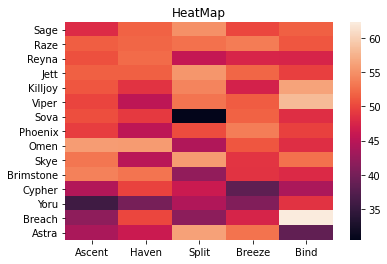

```python
plt.title("HeatMap")
sns.heatmap(mapWR)
plt.show()
```

### Predicting Win Ratio

With the rise of popular tournaments, predicting win ratio can be helpful in determining who wins each game, there are events hosted by Riot called Pick'Ems where you can get in-game rewards and prizes if you predict the winners of matches correctly. Not only this, but third party websites allow you to bet on the winners of the games with real money as well.

In this last section we will be focusing on how to make a model to predict the winrate of a game based off of the Average combat score of the team. Although earlier I mentioned that due to the different roles average combat score varies, however, every team composition currently composes of the same amount of each role and as such should be okay to use Average combat score. Not only this, but the ACS is the most comprehensive performance indicator for in-game matches that Riot produces.

For this tutorial, we will be focusing on a linear regression model for correlation between ACS and Win-Rate, split the data into a trian and test, then use the LinearRegression to fit the data, finally use sklearn's predict function to create your predictive model.

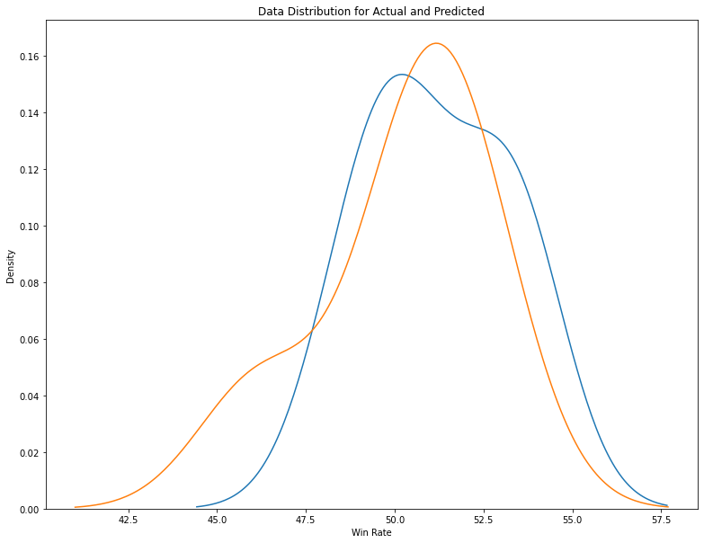

```python
x = compiled.drop("Win Rate", axis = 1)
y = compiled['Win Rate']

# Split data into Train and Test
x_train, x_test, y_train, y_test = model_selection.train_test_split(x, y, test_size=.33, random_state=500)


# Fit the Linear Regression on Train split
lr = LinearRegression().fit(x_train, y_train)

# Predict using Test split
pred = lr.predict(X_test)

f, ax = plt.subplots(figsize=(13,10))
plt.title('Data Distribution for Actual and Predicted')
sns.distplot(y_test, hist=False, label="Actual", ax = ax)
sns.distplot(pred, hist=False, label="Linear Regression Predictions", ax = ax)
```

From above it seems that the model is not terrible in predicting the winrate, however, I do believe hat with more data we can train the predictive model better. With the amount of data that we actually ended up using to create this model, it is a good example of underfitting. You can learn more about how to avoid underfitting and overfitting here: https://www.geeksforgeeks.org/underfitting-and-overfitting-in-machine-learning/

### Conclusion and Future Work

Valorant is currently very popular, however the Riot Games never releases the in-game data out. I learned a lot about this game from looking through all these statistics on the different agents and many trends that I saw for "winning teams" in the professional scene made sense to me. Hopefully this tutorial provided at least some insight on how to get started with not only analyzing large batches of data but also playing Valorant as well.

For future work, I definitely want to have access to more data with the other agens and see if I can actually predict the win-rate of a team based off of team composition alone. Also given the fact that there are professional players, I'd love to be able to access their statistics in professional matches to predict the likelihood of the actual professional team winning against another team.